# `regLine` Plot Regression Line

Kevin O Brien

21 November 2018

#### Description

Plots a regression line on a scatterplot; the line is plotted between the minimum and maximum x-values.

#### Usage

```
regLine(mod, col=carPalette()[2], lwd=2, lty=1,...)
```

#### Arguments

mod a model, such as produced by lm, that responds to the coef function by returning a 2-element vector, whose elements are interpreted respectively as the intercept and slope of a regresison line. * `col`: color for points and lines; the default is the second entry in the current car palette (see carPalette and par). lwd line width; default is 2 (see par). lty line type; default is 1, a solid line (see par). … optional arguments to be passed to the lines plotting function.

#### Examples

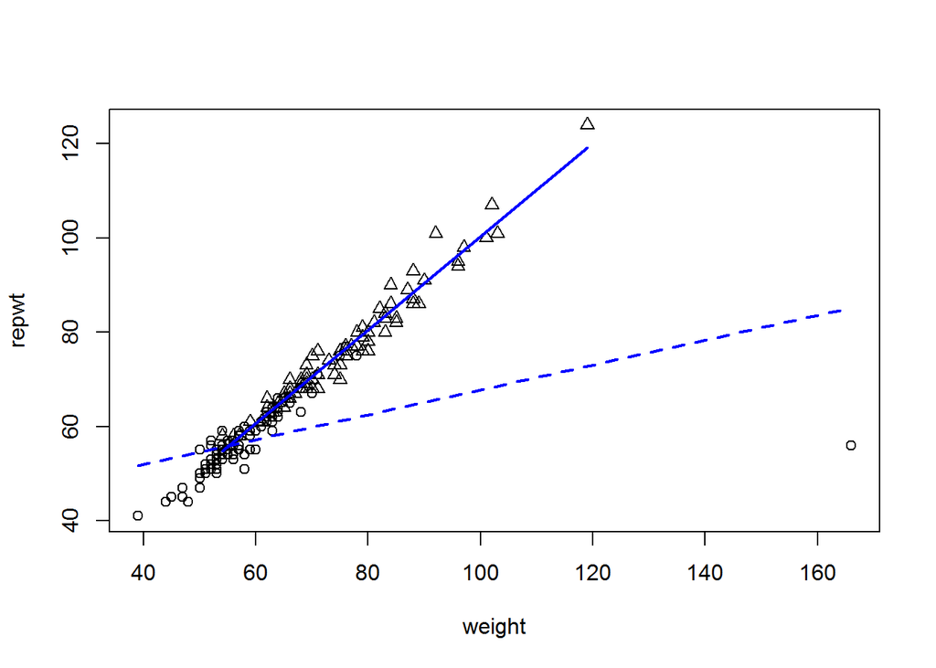

```r
plot(repwt ~ weight, pch=c(1,2)[sex], data=Davis)
regLine(lm(repwt~weight, subset=sex=="M", data=Davis))
regLine(lm(repwt~weight, subset=sex=="F", data=Davis), lty=2)
```

In contrast to abline, this function plots only over the range of the observed x-values. The x-values are extracted from mod as the second column of the model matrix. Value NULL. This function is used for its side effect: adding a line to the plot. Author(s) John Fox jfox@mcmaster.ca See Also abline, lines